# Bloque 2: Árboles de Clasificación y Regresión

Ejemplo paquete `tree`

Profesora: Dra. Diana Paola Montoya Escobar diana.montoya@iteso.mx

Marzo 2023


# Introducción

Recordemos que los **árboles de decisión** son modelos predictivos formados por **reglas binarias (si/no)** con las que se consigue repartir las observaciones en función de sus atributos y predecir así el valor de la variable respuesta.

Muchos métodos predictivos generan modelos globales en los que una única ecuación se aplica a todo el espacio muestral. Cuando el caso de uso implica múltiples predictores, que interaccionan entre ellos de forma compleja y no lineal, es muy difícil encontrar un único modelo global que sea capaz de reflejar la relación entre las variables. Los métodos estadísticos y de machine learning basados en árboles engloban a un conjunto de técnicas supervisadas no paramétricas que consiguen segmentar el espacio de los predictores en regiones simples, dentro de las cuales es más sencillo manejar las interacciones. Es esta característica la que les proporciona gran parte de su potencial.

## Limitaciones de los Árboles de Decisión

Los árboles de decisión tienen la tendencia de sobre-ajustar (overfit). Esto quiere decir que tienden a aprender muy bien los datos de entrenamiento pero su generalización no es tan buena. Una forma de mejorar la generalización de los árboles de decisión es usar regularización. *Para mejorar mucho más la capacidad de generalización de los árboles de decisión, deberemos combinar varios árboles*.

## Recordemos un poco de árboles de regresión

Tras la creación de un árbol de regresión, *el cual podemos calcular sólo para variables continuas*, las observaciones de entrenamiento quedan agrupadas en los nodos terminales. Para predecir una nueva observación, se recorre el árbol en función de los valores que tienen sus predictores hasta llegar a uno de los nodos terminales.

En el caso de regresión, el valor predicho suele ser la media de la variable respuesta de las observaciones de entrenamiento que están en ese mismo nodo. Si bien la media es el valor más empleado, se puede utilizar cualquier otro (mediana, cuantil, etc).

Supongamos que se dispone de 10 observaciones, cada una con un valor de variable respuesta Y y unos predictores X.

| id | 1 | 2 | 3 | 4 | 5 | 6 | 7 | 8 | 9 | 10 |
| --- | --- | --- | --- | --- | --- | --- | --- | --- | --- | --- |
| Y | 10 | 18 | 24 | 8 | 2 | 9 | 16 | 10 | 20 | 14 |
| X | … | … | … | … | … | … | … | … | … | … |

La siguiente imagen muestra cómo sería la predicción del árbol para una nueva observación. El camino hasta llegar al nodo final está resaltado. En cada nodo terminal se detalla el índice de las observaciones de entrenamiento que forman parte. Donde, el camino hasta llegar al nodo final está resaltado. En cada nodo terminal se detalla el índice de las observaciones de entrenamiento que forman parte del árbol.

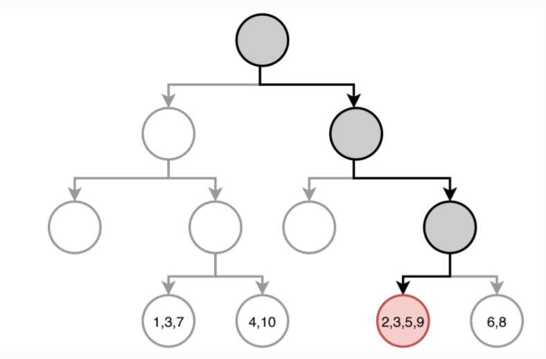

El valor predicho por el árbol es la media de la variable respuesta Y de las observaciones con *id*: 2, 3, 5, 9.

$$\hat{\mu}=\frac{18+24+2+20}{4}=16$$

Aunque la anterior es la forma más común de obtener las predicciones de un árbol de regresión, existe otra aproximación. La predicción de un árbol de regresión puede verse como una variante de vecinos cercanos en la que, solo las observaciones que forman parte del mismo nodo terminal que la observación predicha, tienen influencia. Siguiendo esta aproximación, la predicción del árbol se define como la media ponderada de todas las observaciones de entrenamiento, donde el peso de cada observación depende únicamente de si forma parte o no del mismo nodo terminal.

$$\hat{\mu}=\sum_{i=1}^{n}w_iY_i$$

El valor de las posiciones del vector de pesos $w$ es 1 para las observaciones que están en el mismo nodo y $0$ para el resto. En este ejemplo sería:
$$w_(0,1,1,0,1,0,0,0,1,0)$$

Para que la suma de todos los pesos sea 1, se dividen por el número total de observaciones en el nodo terminal seleccionado, en este caso 4, decir, hacemos una normalización.
$$w= (0,1/4,1/4,0,1/4,0,0,0,1/4,0)$$
y así tenemos el mismo valor:
$$\hat{\mu}=16$$

### Evitar el overfitting

El proceso de construcción de árboles descrito en las secciones anteriores tiende a reducir rápidamente el error de entrenamiento, es decir, el modelo se ajusta muy bien a las observaciones empleadas como entrenamiento. Como consecuencia, se genera un *overfitting* que reduce su capacidad predictiva al aplicarlo a nuevos datos. La razón de este comportamiento radica en la facilidad con la que los árboles se ramifican adquiriendo estructuras complejas. De hecho, si no se limitan las divisiones, todo árbol termina ajustándose perfectamente a las observaciones de entrenamiento creando un nodo terminal por observación. Existen dos estrategias para prevenir el problema de overfitting de los árboles: limitar el tamaño del árbol (parada temprana o *early stopping*) y el proceso de podado (*pruning*).

### Ejemplo de regresión

#### Librerias

Para este ejemplo utilizaremos las siguientes librerías. Recuerda que si no tienes intalado alguno de los paquetes, debes, antes de correr las librerias, instalar el paquete con la función `install.packages()` y entre comillas (“) escribes el nombre del paquete.

```r
# Tratamiento de datos
library(MASS) # Para el conjunto de datos utilizado
library(dplyr)
```

```r
library(tidyr)
library(skimr)

# Gráficos
library(ggplot2)
library(ggpubr)

# Preprocesado y modelado
library(tree)
```

#### Datos

El conjunto de datos que utilizaremos se llama `Boston`, que se encuentra dentro del paquete de `MASS` contiene precios de viviendas de la ciudad de Boston, así como información socioeconómica del barrio en el que se encuentran. Se pretende ajustar un modelo de regresión que permita predecir el precio medio de una vivienda (`medv`) en función de las variables disponibles.

```r
data("Boston")
datos <- Boston
head(datos,3)
```

|  | crim | zn | indus | chas | nox | rm | age | dis | rad | tax | ptratio | black | lstat | medv |
| --- | --- | --- | --- | --- | --- | --- | --- | --- | --- | --- | --- | --- | --- | --- |
| 1 | 0.00632 | 18 | 2.31 | 0 | 0.538 | 6.575 | 65.2 | 4.0900 | 1 | 296 | 15.3 | 396.90 | 4.98 | 24.0 |
| 2 | 0.02731 | 0 | 7.07 | 0 | 0.469 | 6.421 | 78.9 | 4.9671 | 2 | 242 | 17.8 | 396.90 | 9.14 | 21.6 |
| 3 | 0.02729 | 0 | 7.07 | 0 | 0.469 | 7.185 | 61.1 | 4.9671 | 2 | 242 | 17.8 | 392.83 | 4.03 | 34.7 |

Otra forma de hacer un resumen de los datos es por medio de la función `skim()`:

```r
skim(datos)
```

Data summary

| Name | datos |
| --- | --- |
| Number of rows | 506 |
| Number of columns | 14 |
| _______________________ |  |
| Column type frequency: |  |
| numeric | 14 |
| ________________________ |  |
| Group variables | None |

**Variable type: numeric**

| skim_variable | n_missing | complete_rate | mean | sd | p0 | p25 | p50 | p75 | p100 | hist |
| --- | --- | --- | --- | --- | --- | --- | --- | --- | --- | --- |
| crim | 0 | 1 | 3.61 | 8.60 | 0.01 | 0.08 | 0.26 | 3.68 | 88.98 | ▇▁▁▁▁ |
| zn | 0 | 1 | 11.36 | 23.32 | 0.00 | 0.00 | 0.00 | 12.50 | 100.00 | ▇▁▁▁▁ |
| indus | 0 | 1 | 11.14 | 6.86 | 0.46 | 5.19 | 9.69 | 18.10 | 27.74 | ▇▆▁▇▁ |
| chas | 0 | 1 | 0.07 | 0.25 | 0.00 | 0.00 | 0.00 | 0.00 | 1.00 | ▇▁▁▁▁ |
| nox | 0 | 1 | 0.55 | 0.12 | 0.38 | 0.45 | 0.54 | 0.62 | 0.87 | ▇▇▆▅▁ |
| rm | 0 | 1 | 6.28 | 0.70 | 3.56 | 5.89 | 6.21 | 6.62 | 8.78 | ▁▂▇▂▁ |
| age | 0 | 1 | 68.57 | 28.15 | 2.90 | 45.02 | 77.50 | 94.07 | 100.00 | ▂▂▂▃▇ |
| dis | 0 | 1 | 3.80 | 2.11 | 1.13 | 2.10 | 3.21 | 5.19 | 12.13 | ▇▅▂▁▁ |
| rad | 0 | 1 | 9.55 | 8.71 | 1.00 | 4.00 | 5.00 | 24.00 | 24.00 | ▇▂▁▁▃ |
| tax | 0 | 1 | 408.24 | 168.54 | 187.00 | 279.00 | 330.00 | 666.00 | 711.00 | ▇▇▃▁▇ |
| ptratio | 0 | 1 | 18.46 | 2.16 | 12.60 | 17.40 | 19.05 | 20.20 | 22.00 | ▁▃▅▅▇ |
| black | 0 | 1 | 356.67 | 91.29 | 0.32 | 375.38 | 391.44 | 396.22 | 396.90 | ▁▁▁▁▇ |
| lstat | 0 | 1 | 12.65 | 7.14 | 1.73 | 6.95 | 11.36 | 16.96 | 37.97 | ▇▇▅▂▁ |
| medv | 0 | 1 | 22.53 | 9.20 | 5.00 | 17.02 | 21.20 | 25.00 | 50.00 | ▂▇▅▁▁ |

#### Modelo

La función `tree()` del paquete `tree` permite ajustar árboles de decisión (similar al `rpart`. La elección entre árbol de regresión o árbol de clasificación se hace automáticamente dependiendo de si la variable respuesta es de tipo numeric o factor. *Es importante tener en cuenta que solo estos dos tipos de vectores están permitidos, si se pasa uno de tipo character se devuelve un error*.

A continuación, se ajusta un árbol de regresión empleando como variable respuesta `medv` y como predictores todas las variables disponibles. Como en todo estudio de regresión, no solo es importante ajustar el modelo, sino también cuantificar su capacidad para predecir nuevas observaciones. Para poder hacer la posterior evaluación, se dividen los datos en dos grupos, uno de entrenamiento (train) y otro de prueba (test).

La función `tree()` crece el árbol hasta que encuentra una condición de parada. Por defecto, estas condiciones son:

- `mincut`: número mínimo de observaciones que debe de tener al menos uno de los nodos hijos para que se produzca la división.
- `minsize`: número mínimo de observaciones que debe de tener un nodo para que pueda dividirse.

```r
# División de los datos entre test y train
set.seed(123)
train <- sample(1:nrow(datos), size = nrow(datos)/2)
datos_train <- datos[train,]
datos_test  <- datos[-train,]

# Creación y entrenamiento del modelo
set.seed(123)
arbol_regresion <- tree::tree(
                    formula = medv ~ .,
                    data    = datos_train,
                    split   = "deviance",
                    mincut  = 20,
                    minsize = 50
                  )

summary(arbol_regresion)
```

```
##
## Regression tree:
## tree::tree(formula = medv ~ ., data = datos_train, split = "deviance",
##     mincut = 20, minsize = 50)
## Variables actually used in tree construction:
## [1] "rm"    "lstat" "dis"   "tax"
## Number of terminal nodes:  6
## Residual mean deviance:  20.56 = 5078 / 247
## Distribution of residuals:
##     Min.  1st Qu.   Median     Mean  3rd Qu.     Max.
## -14.5500  -2.8680  -0.3628   0.0000   2.0050  22.1300
```

La función `summary()` muestra que, el árbol entrenado, tiene un total de 6 nodos terminales y que se han empleado como predictores las variables `rm`, `lstat`, `dis` y `tax`. En el contexto de árboles de regresión, el término Residual mean deviance es la suma de cuadrados residuales dividida entre (número de observaciones - número de nodos terminales). Cuanto menor es la deviance, mejor es el ajuste del árbol a las observaciones de entrenamiento.

Una vez creado el árbol, se puede representar mediante la combinación de las funciones `plot()` y `text()`. La función `plot()` dibuja la estructura del árbol, las ramas y los nodos. Mediante su argumento `type` se puede especificar si se quiere que todas las ramas tengan el mismo tamaño (`type = "uniform"`) o que su longitud sea proporcional a la reducción de impureza (heterogeneidad) de los nodos terminales (`type = "proportional"`). Esta segunda opción permite identificar visualmente el impacto de cada división en el modelo. La función `text()` añade la descripción de cada nodo interno y el valor de cada nodo terminal.

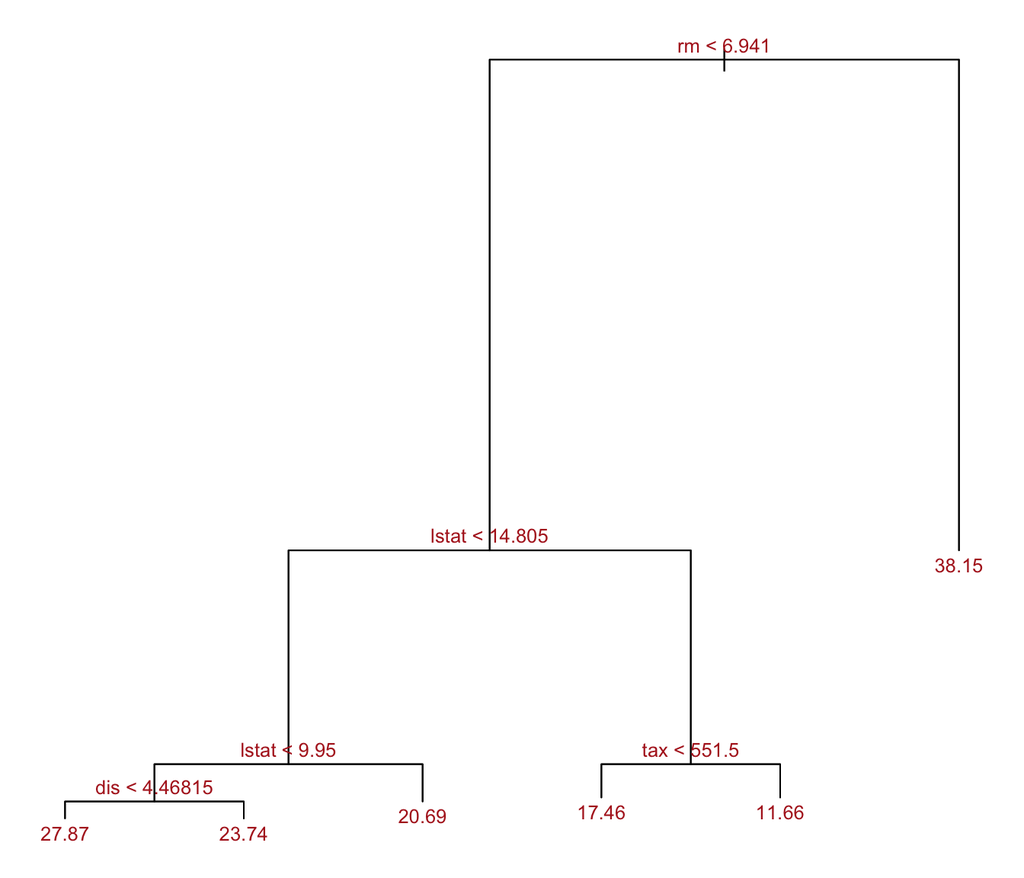

```r
# Estructura del árbol
par(mar = c(1,1,1,1)) # c(bottom, left, top, right)
plot(x = arbol_regresion, type = "proportional")
text(x = arbol_regresion, splits = TRUE, pretty = 0, cex = 0.8, col = "firebrick")
```

#### Podado del árbol (pruning)

La función cv.tree() emplea cross validation para identificar el valor óptimo de penalización. Por defecto, esta función emplea la deviance para guiar el proceso de pruning.

```r
# Pruning (const complexity pruning) por validación cruzada
# El árbol se crece al máximo posible para luego aplicar el pruning
arbol_regresion <- tree(
                    formula = medv ~ .,
                    data    = datos_train,
                    split   = "deviance",
                    mincut  = 1,
                    minsize = 2,
                    mindev  = 0
                  )

# Búsqueda por validación cruzada
set.seed(123)
cv_arbol <- cv.tree(arbol_regresion, K = 5)
cv_arbol
```

```
## $size
##   [1] 210 209 206 195 187 185 184 182 181 177 175 174 170 169 168 167 162 161
##  [19] 159 158 155 153 152 151 150 149 148 147 146 145 143 141 140 138 137 136
##  [37] 135 134 133 131 130 129 128 127 125 124 122 120 119 118 117 116 115 114
##  [55] 113 112 111 110 109 107 106 105 104 103 102 101 100  99  98  97  96  95
##  [73]  94  93  92  90  89  87  86  85  84  83  82  81  80  79  78  77  76  75
##  [91]  74  73  72  71  70  69  68  67  66  65  64  63  61  60  59  58  57  56
## [109]  54  53  52  51  50  49  48  47  46  45  44  43  42  41  40  39  38  37
## [127]  36  35  34  33  32  31  30  29  28  27  26  25  24  23  22  21  20  19
## [145]  18  17  16  14  13  12  11  10   9   8   7   6   5   4   3   2   1
##
## $dev
##   [1]  6996.698  6996.698  6996.698  6996.698  6996.698  6996.698  6996.698
##   [8]  6996.698  6996.698  6996.698  6996.698  6996.698  6996.698  6996.698
##  [15]  6996.698  6996.698  6996.698  6996.698  6996.698  6996.698  6996.698
```

[output cut: 61 more lines]

El objeto devuelto por `cv.tree()` contiene:

- `size`: el tamaño (número de nodos terminales) de cada árbol.
- `dev`: la estimación de cross-validation test error para cada tamaño de árbol.
- `k`: El rango de valores de penalización α evaluados.
- `method`: El criterio empleado para seleccionar el mejor árbol.

```r
# Tamaño óptimo encontrado
size_optimo <- rev(cv_arbol$size)[which.min(rev(cv_arbol$dev))]
paste("Tamaño óptimo encontrado:", size_optimo)
```

```
## [1] "Tamaño óptimo encontrado: 10"
```

Observemos cómo fueron los resultados para identificar el valor óptimo:

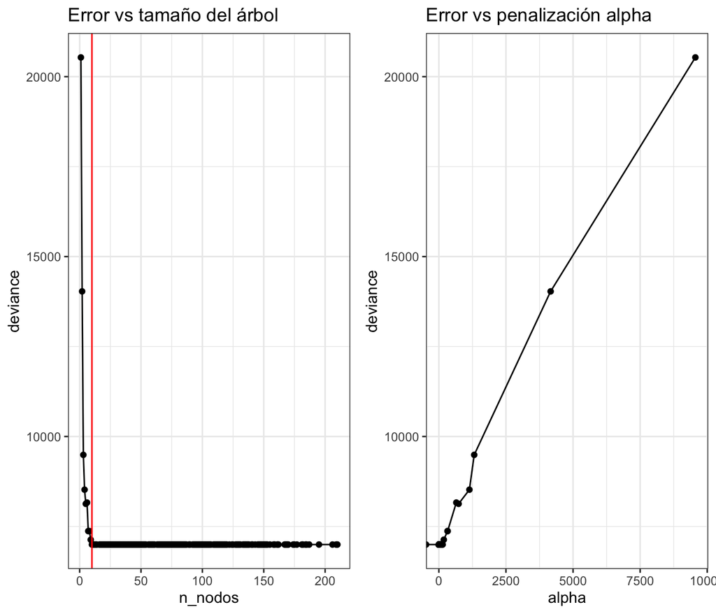

```r
resultados_cv <- data.frame(
                   n_nodos  = cv_arbol$size,
                   deviance = cv_arbol$dev,
                   alpha    = cv_arbol$k
                 )

p1 <- ggplot(data = resultados_cv, aes(x = n_nodos, y = deviance)) +
      geom_line() +
      geom_point() +
      geom_vline(xintercept = size_optimo, color = "red") +
      labs(title = "Error vs tamaño del árbol") +
      theme_bw()

p2 <- ggplot(data = resultados_cv, aes(x = alpha, y = deviance)) +
      geom_line() +
      geom_point() +
      labs(title = "Error vs penalización alpha") +
      theme_bw()

ggarrange(p1, p2)
```

Una vez identificado el valor óptimo de $\alpha$, con la función `prune.tree()` se aplica el podado final. Esta función también acepta el valor de $\alpha$ óptimo en lugar del tamaño.

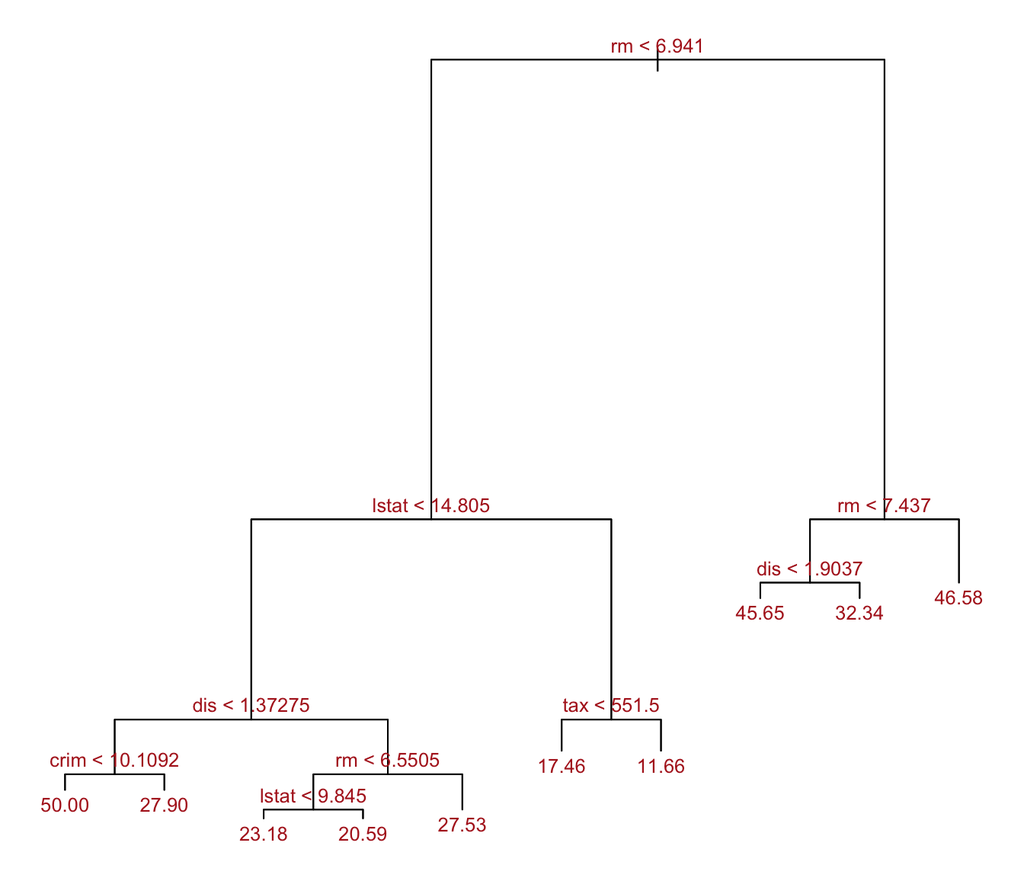

```r
# Estructura del árbol creado final
arbol_final <- prune.tree(
                  tree = arbol_regresion,
                  best = size_optimo
               )

par(mar = c(1,1,1,1))
plot(x = arbol_final, type = "proportional")
text(x = arbol_final, splits = TRUE, pretty = 0, cex = 0.8, col = "firebrick")
```

#### Predicción y evaluación del modelo

Evaluación la capacidad de predición reemplazando los datos de test en el modelo encontrado.

```r
# Error de test del modelo inicial
predicciones <- predict(arbol_regresion, newdata = datos_test)
test_rmse    <- sqrt(mean((predicciones - datos_test$medv)^2))
paste("Error de test (rmse) del árbol inicial, sin pododar:", round(test_rmse,2))
```

```
## [1] "Error de test (rmse) del árbol inicial, sin pododar: 5.43"
```

```r
# Error de test del modelo final
predicciones <- predict(arbol_final, newdata = datos_test)
test_rmse    <- sqrt(mean((predicciones - datos_test$medv)^2))
paste("Error de test (rmse) del árbol final, árbol podado:", round(test_rmse,2))
```

```
## [1] "Error de test (rmse) del árbol final, árbol podado: 5.13"
```

El proceso de pruning consigue reducir el error (*rmse*) del modelo de 5.43 a 5.13. Las predicciones del modelo final se alejan en promedio 5.13 unidades (5130 dólares) del valor real.

## Recordemos árboles de clasificación

Este tipo de árboles sólo los encontramos para variables cualitativas. Tras la creación de un árbol, las observaciones de entrenamiento quedan agrupadas en los nodos terminales. Para predecir una nueva observación, se recorre el árbol en función del valor de sus predictores hasta llegar a uno de los nodos terminales. En el caso de clasificación, suele emplearse la moda de la variable respuesta como valor de predicción, es decir, la clase más frecuente del nodo. Además, puede acompañarse con el porcentaje de cada clase en el nodo terminal, lo que aporta información sobre la confianza de la predicción.

### Ejemplo de clasificación

#### Librerias

```r
# Tratamiento de datos
library(ISLR) # Donde se ecuentra el conjunto de datos
library(dplyr)
library(tidyr)
library(skimr)

# Gráficos
library(ggplot2)
library(ggpubr)

# Preprocesado y modelado
library(tree)
```

#### Datos

El set de datos `Carseats`, disponible en paquete `ISLR`, contiene información sobre la venta de sillas infantiles en 400 tiendas distintas. Para cada una de las 400 tiendas se han registrado 11 variables. Se pretende generar un modelo de clasificación que permita predecir si una tienda tiene ventas altas (Sales > 8) o bajas (Sales <= 8) en función de todas las variables disponibles.

```r
data("Carseats")
datos = Carseats
head(datos, 3)
```

|  | Sales | CompPrice | Income | Advertising | Population | Price | ShelveLoc | Age | Education | Urban | US |
| --- | --- | --- | --- | --- | --- | --- | --- | --- | --- | --- | --- |
| 1 | 9.50 | 138 | 73 | 11 | 276 | 120 | Bad | 42 | 17 | Yes | Yes |
| 2 | 11.22 | 111 | 48 | 16 | 260 | 83 | Good | 65 | 10 | Yes | Yes |
| 3 | 10.06 | 113 | 35 | 10 | 269 | 80 | Medium | 59 | 12 | Yes | Yes |

```r
skim(datos)
```

Data summary

| Name | datos |
| --- | --- |
| Number of rows | 400 |
| Number of columns | 11 |
| _______________________ |  |
| Column type frequency: |  |
| factor | 3 |
| numeric | 8 |
| ________________________ |  |
| Group variables | None |

**Variable type: factor**

| skim_variable | n_missing | complete_rate | ordered | n_unique | top_counts |
| --- | --- | --- | --- | --- | --- |
| ShelveLoc | 0 | 1 | FALSE | 3 | Med: 219, Bad: 96, Goo: 85 |
| Urban | 0 | 1 | FALSE | 2 | Yes: 282, No: 118 |
| US | 0 | 1 | FALSE | 2 | Yes: 258, No: 142 |

**Variable type: numeric**

| skim_variable | n_missing | complete_rate | mean | sd | p0 | p25 | p50 | p75 | p100 | hist |
| --- | --- | --- | --- | --- | --- | --- | --- | --- | --- | --- |
| Sales | 0 | 1 | 7.50 | 2.82 | 0 | 5.39 | 7.49 | 9.32 | 16.27 | ▁▆▇▃▁ |
| CompPrice | 0 | 1 | 124.97 | 15.33 | 77 | 115.00 | 125.00 | 135.00 | 175.00 | ▁▅▇▃▁ |
| Income | 0 | 1 | 68.66 | 27.99 | 21 | 42.75 | 69.00 | 91.00 | 120.00 | ▇▆▇▆▅ |
| Advertising | 0 | 1 | 6.64 | 6.65 | 0 | 0.00 | 5.00 | 12.00 | 29.00 | ▇▃▃▁▁ |
| Population | 0 | 1 | 264.84 | 147.38 | 10 | 139.00 | 272.00 | 398.50 | 509.00 | ▇▇▇▇▇ |
| Price | 0 | 1 | 115.80 | 23.68 | 24 | 100.00 | 117.00 | 131.00 | 191.00 | ▁▂▇▆▁ |
| Age | 0 | 1 | 53.32 | 16.20 | 25 | 39.75 | 54.50 | 66.00 | 80.00 | ▇▆▇▇▇ |
| Education | 0 | 1 | 13.90 | 2.62 | 10 | 12.00 | 14.00 | 16.00 | 18.00 | ▇▇▃▇▇ |

Como `Sales` es una variable continua y el objetivo del estudio es clasificar las tiendas según si venden mucho o poco, se crea una nueva variable dicotómica (Si, No) llamada `ventas_altas`.

```r
datos$ventas_altas <- ifelse(test = datos$Sales > 8,
                             yes = "Si", no = "No")

# Conversión de la variable respuesta a tipo factor
datos$ventas_altas <- as.factor(datos$ventas_altas)

# Una vez creada la nueva variable respuesta se descarta la original
datos$Sales = NULL
```

#### Modelo

Se ajusta un árbol de clasificación empleando como variable respuesta `ventas_altas` y como predictores todas las variables disponibles. Se utilizan en primer lugar `minsize=10`, el resto de los hiperparámetros se dejan por defecto. Después, se aplica el proceso de pruning y se comparan los resultados frente al modelo inicial.

```r
# División de los datos en train y test
set.seed(123)
train <- sample(1:nrow(datos), nrow(datos) / 2, replace = FALSE)
datos_train <- datos[train,]
datos_test  <- datos[-train,]

# Entrenamiento del modelo
set.seed(123)
arbol_clasificacion <- tree(
                        formula = ventas_altas ~ .,
                        data    = datos_train,
                        minsize = 10
                       )
summary(arbol_clasificacion)
```

```
##
## Classification tree:
## tree(formula = ventas_altas ~ ., data = datos_train, minsize = 10)
## Variables actually used in tree construction:
## [1] "ShelveLoc"   "Price"       "Income"      "CompPrice"   "Advertising"
## [6] "Age"         "Education"   "Population"  "US"
## Number of terminal nodes:  20
## Residual mean deviance:  0.5056 = 91.02 / 180
## Misclassification error rate: 0.115 = 23 / 200
```

La función `summary()` muestra que el árbol ajustado tiene un total de 20 nodos terminales y un *classification error rate* de entrenamiento del 11.5%. La deviance de los árboles de clasificación se calcula como $-2\sum_m\sum_k n_{mk}\log(\hat{p}_{mk})$, donde $n_{mk}$ es el número de observaciones en el nodo terminal $m$ que pertenecen a la clase $k$. El término *Residual mean deviance* mostrado en el `summary` es simplemente la deviance dividida entre (número de observaciones - número de nodos terminales). Cuanto menor es la *deviance* mejor es el ajuste del árbol a las observaciones de entrenamiento.

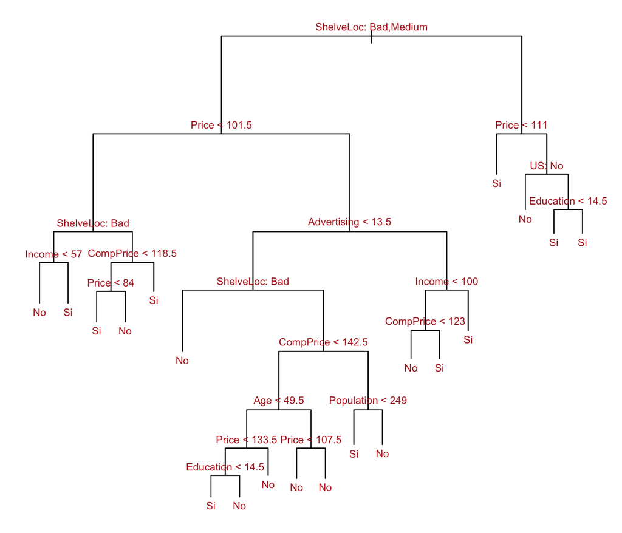

```r
par(mar = c(1,1,1,1))
plot(x = arbol_clasificacion, type = "proportional")
text(x = arbol_clasificacion, splits = TRUE, pretty = 0, cex = 0.7, col = "firebrick")
```

#### Predicción y evaluación del modelo

```r
# Error de test del modelo
predicciones <- predict(
                  arbol_clasificacion,
                  newdata = datos_test,
                  type    = "class"
                )
table(predicciones, datos_test$ventas_altas)
```

```
##
## predicciones No Si
##           No 87 13
##           Si 35 65
```

#### Poda del árbol

Con la finalidad de reducir la varianza del modelo y así disminuir el *test error*, se somete al árbol a un proceso de *pruning*. A diferencia del ejemplo anterior, al ser este un árbol de clasificación se indica en la función `cv.tree()` que `FUN = prune.misclass`. De esta manera se emplea el classification error rate para guiar el proceso de *pruning*.

```r
# Pruning (const complexity pruning) por validación cruzada
# El árbol se crece al máximo posible para luego aplicar el pruning
arbol_clasificacion <- tree(
                          formula = ventas_altas ~ .,
                          data    = datos_train,
                          mincut  = 1,
                          minsize = 2,
                          mindev  = 0
                       )

# Búsqueda por validación cruzada
set.seed(123)
cv_arbol <- cv.tree(arbol_clasificacion, FUN = prune.misclass, K = 5)
```

```r
# Tamaño óptimo encontrado
size_optimo <- rev(cv_arbol$size)[which.min(rev(cv_arbol$dev))]
size_optimo
```

```
## [1] 33
```

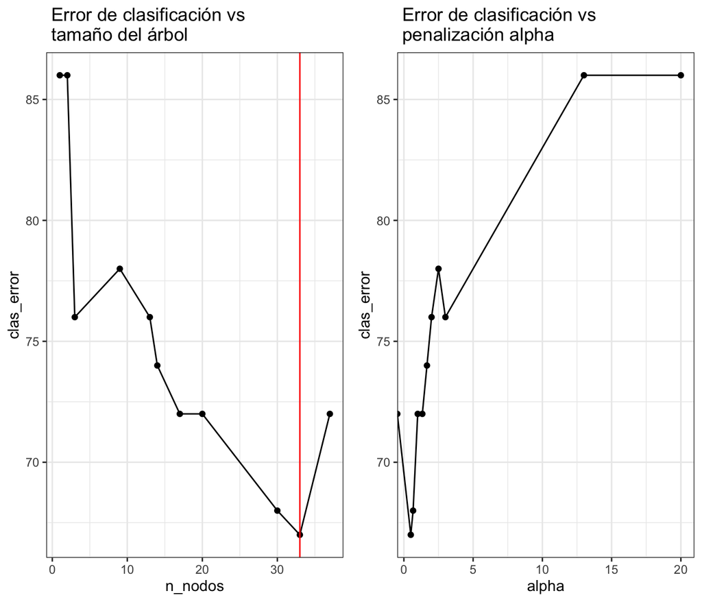

```r
resultados_cv <- data.frame(n_nodos = cv_arbol$size, clas_error = cv_arbol$dev,
                            alpha = cv_arbol$k)

p1 <- ggplot(data = resultados_cv, aes(x = n_nodos, y = clas_error)) +
      geom_line() +
      geom_point() +
      geom_vline(xintercept = size_optimo, color = "red") +
      labs(title = " Error de clasificación vs \n tamaño del árbol") +
      theme_bw()

p2 <- ggplot(data = resultados_cv, aes(x = alpha, y = clas_error)) +
      geom_line() +
      geom_point() +
      labs(title = " Error de clasificación vs \n penalización alpha") +
      theme_bw()

ggarrange(p1, p2)
```

En este caso, un árbol con 33 nodos terminales minimiza el *test error*.

Con la función `prune.missclas()` se obtiene el mejor árbol de clasificación del tamaño identificado como óptimo (no confundir con la función `prune.tree()` para árboles de regresión). A esta función también se le puede indicar el valor de $\alpha$ óptimo en lugar del tamaño.

```r
arbol_final <- prune.misclass(
                  tree = arbol_clasificacion,
                  best = size_optimo
               )

# Error de test del modelo final
predicciones <- predict(arbol_clasificacion, newdata = datos_test, type = "class")
table(predicciones, datos_test$ventas_altas)
```

```
##
## predicciones No Si
##           No 95 16
##           Si 27 62
```

```r
paste("El porcentaje de acierto es de",
      100 * ((95 + 62) / (95 + 62 + 16 + 27)), "%")
```

```
## [1] "El porcentaje de acierto es de 78.5 %"
```

# Referencias

- [Modelos Predictivos](https://fhernanb.github.io/libro_mod_pred/index.html), Freddy Hernández, 2019.
- [Árboles de decisión, random forest, gradient boosting y C5.0](https://www.cienciadedatos.net/documentos/33_arboles_decision_random_forest_gradient_boosting_c50#Idea_intuitiva), Joaquín Amat, 2020